# Complete Walk Through Functional Regression (Open-Air)

Ryan Duffy

2023-03-15

```r
library(openair)
library(tidyverse)
library(fda)
```

```r
library(maptools)
library(lubridate)
```

# 1 Initial Data

```r
#gets data for scottish sites
scottish_site_codes <- importMeta(source = "aurn",all=TRUE) %>%

  #Filters For Scottish Sights
  filter(str_detect(zone, paste(c("Scottish","Highland","Scotland"), collapse = "|"))) %>%

  #Filters For Sites With Start Date less than 2018 and That are still measuring
  filter(year(start_date) < 2019 & end_date=="ongoing") %>%

  # Filters For Sites Measuring PM2.5
  filter(variable == "PM2.5") %>%

  dplyr::select(code) %>%
  unique() %>% t() %>% as.vector()

# imports data for scottish stations for 2018 to 2022
raw_data <- importAURN(

  site=scottish_site_codes[-1],
  year=2019,
  pollutant="pm2.5"

)
```

Now that I have my raw data I want to visualise it.

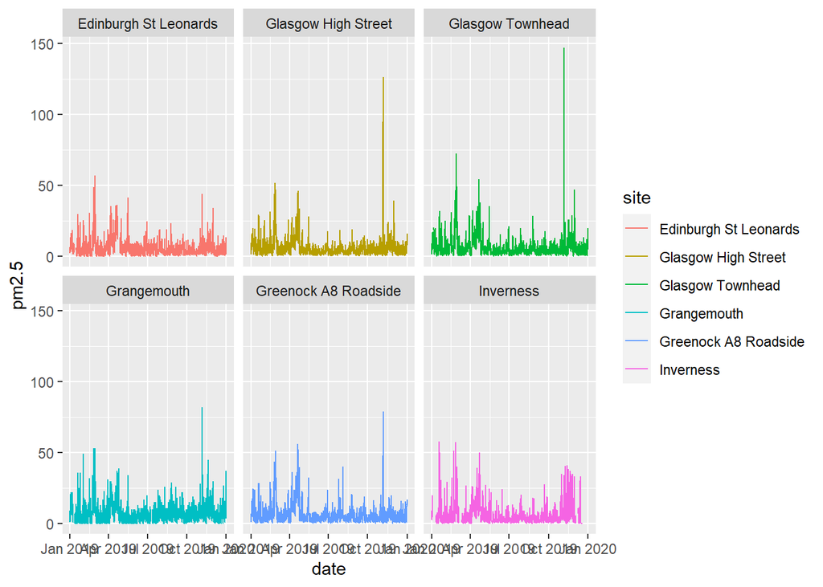

```r
raw_data_longer <- raw_data %>%
  dplyr::select(date,site,pm2.5) %>%
  #converts negative values to 0
  mutate(pm2.5=replace(pm2.5,pm2.5<0,0))

raw_data_wider <- pivot_wider(data = raw_data_longer,names_from = "site",values_from = "pm2.5")

# Plots NOx emissions over time for each station
ggplot(raw_data_longer,aes(x=date,y=pm2.5,col=site))+
  geom_line()+
  facet_wrap(~site)
```

Can see that there are some NA observations. There is a substancial enough amount of them that they need filled. Lets create a new dataset with NAs removed.

```r
#removes rows from data which contain NAs
data_wide_nona <- raw_data_wider %>%
  na.omit()

data_longer_nona <- data_wide_nona %>%
  pivot_longer(cols=c(2:length(colnames(data_wide_nona))),values_to = 'pm2.5',names_to = 'site')
```

- Basis of FDA is that there is some function which produces observations
- We want to estimate this function
- We do not need all observations from every single time point to fit a function
- We can backfill missing data for some stations by fitting functions to our observed data with time points with NAs for at least one station removed.
- If this function is determined to fit well then this can be taken as estimate of our function.
- Can then refit our function using these new values to get estimates for stations which do not have values for these time points with NAs
- So lets fit function the function to our data

First need a set of basis functions. Remember assumption is:

$$\begin{equation}
Y_i = \sum_{i=1}^Kc_i\phi_i(t) + \epsilon_i = \boldsymbol{c\phi(t)'}+ \epsilon_i = \boldsymbol{c'\phi(t)} + \epsilon_i
\tag{1.1}
\end{equation}$$

In this $\epsilon_i \sim N(0,\sigma^2)$ and are iid. Since $\sum_{i=1}^Kc_i\phi_i(t)$ is not a random variable this means that $Y_i\sim N(f(t),\sigma^2)$ and they are also assumed to be iid. We will check this assumption later.

- Going to use B-Spline basis to estimate
- B-Spline functions estimate non-periodic data
- Too many data points so cant use smoothing splines (1 knot at each data point)
- Therefore using penalised regression splines
- Going to use 70 basis functions on an evenly spaced grid
- I first need to convert time into a format readable by fda package in order to create B-Splines
- This is numeric form gives the number of seconds that have passed between your date and 1/1/1970.
- Then going to squish into a 0 to 1 range and store info to convert back if needed
- Called normalisation, Subtract minimum and divide by range.

```r
obs_times <-  as.numeric(raw_data_wider$date)

min_time <- min(obs_times)
range_time <- abs(diff(range(obs_times)))

time_to_use <- function(vector){

  times <- as.numeric(vector)

  return((times-min_time)/range_time)

}

use_to_time_nona <- function(vector){

  times <- as.numeric(vector)

  return((times+min_time)*range_time)

}

obs_data_nona <- data_longer_nona %>%
  mutate(date=time_to_use(date))

obs_data <- raw_data_longer %>%
  mutate(date=time_to_use(date))
```

- Then have to store all observed time points in both our original and no NAs data.
- We will use these to find the range we need our functions to be fitted over and we will also them later.
- We want our functions to be defined over domain of all observed data so we can predict from it for these values
- We can then create our basis using fda package
- Also helpful to extract sites at this point

```r
obs_times <-  time_to_use(raw_data_wider$date)

obs_times_nona <- obs_data_nona$date

sites <- unique(obs_data$site)

basis_pm2.5 <- create.bspline.basis(range(obs_times),nbasis = 70,norder=4)
```

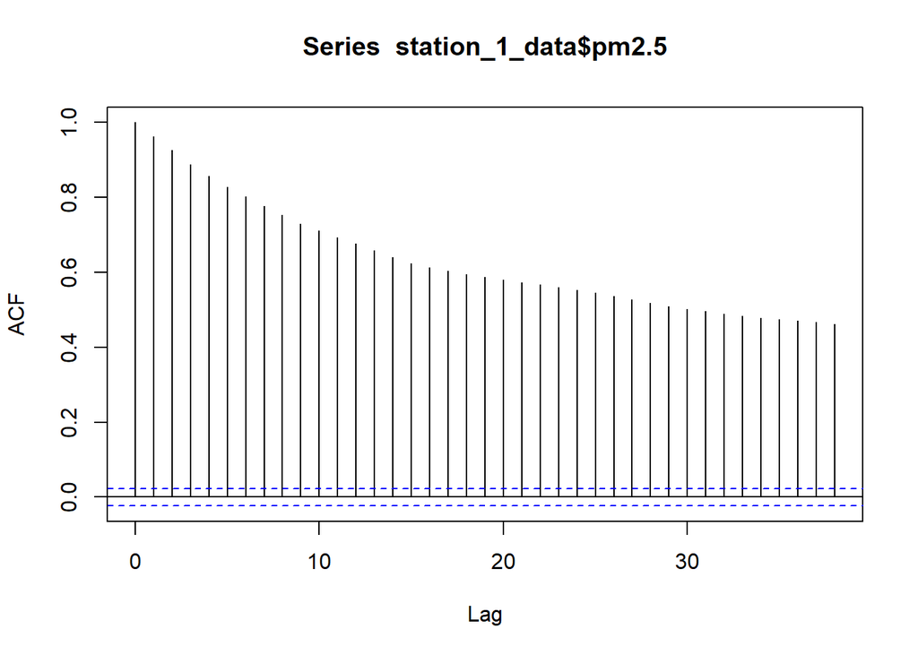

```r
station_1_data <- obs_data_nona %>%
  filter(site==sites[5]) %>%
  arrange(date)

acf(station_1_data$pm2.5)
```

- Need to find coefficients
- Use smoothing
- When residuals are assumed to be independent we want to minimise
- Use second derivative to penalise wigglyness

$$\begin{equation}
F(f)&=\sum_j[Y_j-f(t_j)]^2+\lambda\int_{t_0}^{t_1}[f''(t)]^2dt
\tag{1.2}
\end{equation}$$

- Using basis expansion and converting to vectors and matrice form (taken from Ramsey Book chapter 5):

$$\begin{align}
F(f) &= (\boldsymbol{Y}-\boldsymbol{\phi c'})(\boldsymbol{Y}-\boldsymbol{\phi c'})'+\lambda\int_{t_0}^{t_1}[\boldsymbol{c\phi(t)'}]''^2dt \\
F(f) &= (\boldsymbol{Y}-\boldsymbol{\phi c'})(\boldsymbol{Y}-\boldsymbol{\phi c'})'+\lambda\boldsymbol{c}'\int_{t_0}^{t_1}\boldsymbol{\phi''(t)}\boldsymbol{\phi''(t)'}dt \boldsymbol{c} \\
F(f) &= (\boldsymbol{Y}-\boldsymbol{\phi c'})(\boldsymbol{Y}-\boldsymbol{\phi c'})'+\lambda\boldsymbol{c}'\boldsymbol{R} \boldsymbol{c}
\end{align}$$

List of Assumption Made:

Addressed:

Unaddressed:

- Errors are Normal iid